# AI Workshop 2

- Bruno Alvarenga Colturato, 11200251
- Che Fan Pan, 11200421
- Eduardo Cavalari Valença, 11234381

```python
# Import libraries
import pandas
import seaborn
import numpy as np
```

```python
# Define datasets names
datasets_names = ['CS GO Round Winner Classification',
            'Breast Cancer Dataset',
            'Diabetes',
            'NBA Players Career Duration',
            'Employee Future Prediction',
            'Go To College',
            'Phishing website Detector',
            'Body signal of smoking',
            'Ad Click Prediction',
            'Water quality']

datasets_files = list(map(lambda x : 'datasets/' + x + '.csv', datasets_names))
datasets = [None] * 10
```

# Pre-processing

### CS:GO Round Winner Classification

Predict who wins individual snapshots of rounds: terrorist or counter terrorists.

[Link to source](https://www.kaggle.com/datasets/christianlillelund/csgo-round-winner-classification)

```python
# Load data and drop empty rows
datasets[0] = pandas.read_csv(datasets_files[0])
datasets[0] = datasets[0].dropna(axis=0)

# Transform categorical data into many binary data
datasets[0] = pandas.get_dummies(datasets[0], columns=["map"])

# Define target column
datasets[0] = datasets[0].rename(columns={'round_winner' : 'target'})

datasets[0]
```

|  | time_left | ct_score | t_score | bomb_planted | ct_health | t_health | ct_armor | t_armor | ct_money | t_money | ... | t_grenade_decoygrenade | target | map_de_cache | map_de_dust2 | map_de_inferno | map_de_mirage | map_de_nuke | map_de_overpass | map_de_train | map_de_vertigo |
| --- | --- | --- | --- | --- | --- | --- | --- | --- | --- | --- | --- | --- | --- | --- | --- | --- | --- | --- | --- | --- | --- |
| 0 | 175.00 | 0.0 | 0.0 | False | 500.0 | 500.0 | 0.0 | 0.0 | 4000.0 | 4000.0 | ... | 0.0 | CT | 0 | 1 | 0 | 0 | 0 | 0 | 0 | 0 |
| 1 | 156.03 | 0.0 | 0.0 | False | 500.0 | 500.0 | 400.0 | 300.0 | 600.0 | 650.0 | ... | 0.0 | CT | 0 | 1 | 0 | 0 | 0 | 0 | 0 | 0 |
| 2 | 96.03 | 0.0 | 0.0 | False | 391.0 | 400.0 | 294.0 | 200.0 | 750.0 | 500.0 | ... | 0.0 | CT | 0 | 1 | 0 | 0 | 0 | 0 | 0 | 0 |
| 3 | 76.03 | 0.0 | 0.0 | False | 391.0 | 400.0 | 294.0 | 200.0 | 750.0 | 500.0 | ... | 0.0 | CT | 0 | 1 | 0 | 0 | 0 | 0 | 0 | 0 |
| 4 | 174.97 | 1.0 | 0.0 | False | 500.0 | 500.0 | 192.0 | 0.0 | 18350.0 | 10750.0 | ... | 0.0 | CT | 0 | 1 | 0 | 0 | 0 | 0 | 0 | 0 |
| ... | ... | ... | ... | ... | ... | ... | ... | ... | ... | ... | ... | ... | ... | ... | ... | ... | ... | ... | ... | ... | ... |
| 122405 | 15.41 | 11.0 | 14.0 | True | 200.0 | 242.0 | 195.0 | 359.0 | 100.0 | 5950.0 | ... | 0.0 | T | 0 | 0 | 0 | 0 | 0 | 0 | 1 | 0 |
| 122406 | 174.93 | 11.0 | 15.0 | False | 500.0 | 500.0 | 95.0 | 175.0 | 11500.0 | 23900.0 | ... | 0.0 | T | 0 | 0 | 0 | 0 | 0 | 0 | 1 | 0 |
| 122407 | 114.93 | 11.0 | 15.0 | False | 500.0 | 500.0 | 495.0 | 475.0 | 1200.0 | 6700.0 | ... | 0.0 | T | 0 | 0 | 0 | 0 | 0 | 0 | 1 | 0 |
| 122408 | 94.93 | 11.0 | 15.0 | False | 500.0 | 500.0 | 495.0 | 475.0 | 1200.0 | 6700.0 | ... | 0.0 | T | 0 | 0 | 0 | 0 | 0 | 0 | 1 | 0 |
| 122409 | 74.93 | 11.0 | 15.0 | False | 375.0 | 479.0 | 395.0 | 466.0 | 1100.0 | 7000.0 | ... | 0.0 | T | 0 | 0 | 0 | 0 | 0 | 0 | 1 | 0 |

122410 rows × 104 columns

### Breast Cancer Dataset

Binary classification for type of breast cancer: benign or malignant.

[Link to source](https://www.kaggle.com/datasets/yasserh/breast-cancer-dataset)

```python
# Load data and drop empty rows
datasets[1] = pandas.read_csv(datasets_files[1])
datasets[1] = datasets[1].dropna(axis=0)

# Drop useless column
datasets[1] = datasets[1].drop(columns=['id'])

# Define target column
datasets[1] = datasets[1].rename(columns={'diagnosis' : 'target'})

datasets[1]
```

|  | target | radius_mean | texture_mean | perimeter_mean | area_mean | smoothness_mean | compactness_mean | concavity_mean | concave points_mean | symmetry_mean | ... | radius_worst | texture_worst | perimeter_worst | area_worst | smoothness_worst | compactness_worst | concavity_worst | concave points_worst | symmetry_worst | fractal_dimension_worst |
| --- | --- | --- | --- | --- | --- | --- | --- | --- | --- | --- | --- | --- | --- | --- | --- | --- | --- | --- | --- | --- | --- |
| 0 | M | 17.99 | 10.38 | 122.80 | 1001.0 | 0.11840 | 0.27760 | 0.30010 | 0.14710 | 0.2419 | ... | 25.380 | 17.33 | 184.60 | 2019.0 | 0.16220 | 0.66560 | 0.7119 | 0.2654 | 0.4601 | 0.11890 |
| 1 | M | 20.57 | 17.77 | 132.90 | 1326.0 | 0.08474 | 0.07864 | 0.08690 | 0.07017 | 0.1812 | ... | 24.990 | 23.41 | 158.80 | 1956.0 | 0.12380 | 0.18660 | 0.2416 | 0.1860 | 0.2750 | 0.08902 |
| 2 | M | 19.69 | 21.25 | 130.00 | 1203.0 | 0.10960 | 0.15990 | 0.19740 | 0.12790 | 0.2069 | ... | 23.570 | 25.53 | 152.50 | 1709.0 | 0.14440 | 0.42450 | 0.4504 | 0.2430 | 0.3613 | 0.08758 |
| 3 | M | 11.42 | 20.38 | 77.58 | 386.1 | 0.14250 | 0.28390 | 0.24140 | 0.10520 | 0.2597 | ... | 14.910 | 26.50 | 98.87 | 567.7 | 0.20980 | 0.86630 | 0.6869 | 0.2575 | 0.6638 | 0.17300 |
| 4 | M | 20.29 | 14.34 | 135.10 | 1297.0 | 0.10030 | 0.13280 | 0.19800 | 0.10430 | 0.1809 | ... | 22.540 | 16.67 | 152.20 | 1575.0 | 0.13740 | 0.20500 | 0.4000 | 0.1625 | 0.2364 | 0.07678 |
| ... | ... | ... | ... | ... | ... | ... | ... | ... | ... | ... | ... | ... | ... | ... | ... | ... | ... | ... | ... | ... | ... |
| 564 | M | 21.56 | 22.39 | 142.00 | 1479.0 | 0.11100 | 0.11590 | 0.24390 | 0.13890 | 0.1726 | ... | 25.450 | 26.40 | 166.10 | 2027.0 | 0.14100 | 0.21130 | 0.4107 | 0.2216 | 0.2060 | 0.07115 |
| 565 | M | 20.13 | 28.25 | 131.20 | 1261.0 | 0.09780 | 0.10340 | 0.14400 | 0.09791 | 0.1752 | ... | 23.690 | 38.25 | 155.00 | 1731.0 | 0.11660 | 0.19220 | 0.3215 | 0.1628 | 0.2572 | 0.06637 |
| 566 | M | 16.60 | 28.08 | 108.30 | 858.1 | 0.08455 | 0.10230 | 0.09251 | 0.05302 | 0.1590 | ... | 18.980 | 34.12 | 126.70 | 1124.0 | 0.11390 | 0.30940 | 0.3403 | 0.1418 | 0.2218 | 0.07820 |
| 567 | M | 20.60 | 29.33 | 140.10 | 1265.0 | 0.11780 | 0.27700 | 0.35140 | 0.15200 | 0.2397 | ... | 25.740 | 39.42 | 184.60 | 1821.0 | 0.16500 | 0.86810 | 0.9387 | 0.2650 | 0.4087 | 0.12400 |
| 568 | B | 7.76 | 24.54 | 47.92 | 181.0 | 0.05263 | 0.04362 | 0.00000 | 0.00000 | 0.1587 | ... | 9.456 | 30.37 | 59.16 | 268.6 | 0.08996 | 0.06444 | 0.0000 | 0.0000 | 0.2871 | 0.07039 |

569 rows × 31 columns

### Diabetes

Binary classification for diabetes diagnosis.

[Link to source](https://www.kaggle.com/datasets/tigganeha4/diabetes-dataset-2019/metadata)

```python
# Load data and drop empty rows
datasets[2] = pandas.read_csv(datasets_files[2])
datasets[2] = datasets[2].dropna(axis=0)

# Transform categorical data into many binary data
columns2 = datasets[2].columns.values.tolist()
columns2.remove('Diabetic')
datasets[2] = pandas.get_dummies(datasets[2], columns=columns2)

# Define target column
datasets[2] = datasets[2].rename(columns={'Diabetic' : 'target'})

datasets[2]
```

|  | target | Age_40-49 | Age_50-59 | Age_60 or older | Age_less than 40 | Gender_Female | Gender_Male | Family_Diabetes_no | Family_Diabetes_yes | highBP_no | ... | BPLevel_normal | Pregancies_0.0 | Pregancies_1.0 | Pregancies_2.0 | Pregancies_3.0 | Pregancies_4.0 | Pdiabetes_0 | Pdiabetes_yes | UriationFreq_not much | UriationFreq_quite often |
| --- | --- | --- | --- | --- | --- | --- | --- | --- | --- | --- | --- | --- | --- | --- | --- | --- | --- | --- | --- | --- | --- |
| 0 | no | 0 | 1 | 0 | 0 | 0 | 1 | 1 | 0 | 0 | ... | 0 | 1 | 0 | 0 | 0 | 0 | 1 | 0 | 1 | 0 |
| 1 | no | 0 | 1 | 0 | 0 | 0 | 1 | 1 | 0 | 0 | ... | 0 | 1 | 0 | 0 | 0 | 0 | 1 | 0 | 1 | 0 |
| 2 | no | 1 | 0 | 0 | 0 | 0 | 1 | 1 | 0 | 1 | ... | 0 | 1 | 0 | 0 | 0 | 0 | 1 | 0 | 1 | 0 |
| 3 | no | 0 | 1 | 0 | 0 | 0 | 1 | 1 | 0 | 1 | ... | 0 | 1 | 0 | 0 | 0 | 0 | 1 | 0 | 1 | 0 |
| 4 | no | 1 | 0 | 0 | 0 | 0 | 1 | 1 | 0 | 1 | ... | 0 | 1 | 0 | 0 | 0 | 0 | 1 | 0 | 1 | 0 |
| ... | ... | ... | ... | ... | ... | ... | ... | ... | ... | ... | ... | ... | ... | ... | ... | ... | ... | ... | ... | ... | ... |
| 946 | yes | 0 | 0 | 0 | 1 | 0 | 1 | 0 | 1 | 1 | ... | 0 | 1 | 0 | 0 | 0 | 0 | 1 | 0 | 1 | 0 |
| 947 | yes | 0 | 0 | 1 | 0 | 0 | 1 | 0 | 1 | 0 | ... | 0 | 1 | 0 | 0 | 0 | 0 | 1 | 0 | 0 | 1 |
| 948 | no | 0 | 0 | 1 | 0 | 0 | 1 | 1 | 0 | 0 | ... | 0 | 1 | 0 | 0 | 0 | 0 | 1 | 0 | 1 | 0 |
| 949 | no | 0 | 0 | 1 | 0 | 0 | 1 | 1 | 0 | 0 | ... | 0 | 1 | 0 | 0 | 0 | 0 | 1 | 0 | 1 | 0 |
| 950 | yes | 0 | 0 | 1 | 0 | 1 | 0 | 0 | 1 | 0 | ... | 0 | 0 | 0 | 1 | 0 | 0 | 1 | 0 | 0 | 1 |

905 rows × 91 columns

### NBA Players Career Duration

Will NBA Rookies' Careers last for 5 years or not?

[Link to source](https://www.kaggle.com/datasets/sveneschlbeck/nba-players-career-duration)

```python
# Load data and drop empty rows
datasets[3] = pandas.read_csv(datasets_files[3])
datasets[3] = datasets[3].dropna(axis=0)

# Drop useless column
datasets[3] = datasets[3].drop(columns=['Column1', 'name'])

# Define target column
datasets[3] = datasets[3].rename(columns={'target_5yrs' : 'target'})

datasets[3]
```

|  | gp | min | pts | fgm | fga | fg | 3p_made | 3pa | 3p | ftm | fta | ft | oreb | dreb | reb | ast | stl | blk | tov | target |
| --- | --- | --- | --- | --- | --- | --- | --- | --- | --- | --- | --- | --- | --- | --- | --- | --- | --- | --- | --- | --- |
| 0 | 36 | 27.4 | 7.4 | 2.6 | 7.6 | 34.7 | 0.5 | 2.1 | 25.0 | 1.6 | 2.3 | 69.9 | 0.7 | 3.4 | 4.1 | 1.9 | 0.4 | 0.4 | 1.3 | 0 |
| 1 | 35 | 26.9 | 7.2 | 2.0 | 6.7 | 29.6 | 0.7 | 2.8 | 23.5 | 2.6 | 3.4 | 76.5 | 0.5 | 2.0 | 2.4 | 3.7 | 1.1 | 0.5 | 1.6 | 0 |
| 2 | 74 | 15.3 | 5.2 | 2.0 | 4.7 | 42.2 | 0.4 | 1.7 | 24.4 | 0.9 | 1.3 | 67.0 | 0.5 | 1.7 | 2.2 | 1.0 | 0.5 | 0.3 | 1.0 | 0 |
| 3 | 58 | 11.6 | 5.7 | 2.3 | 5.5 | 42.6 | 0.1 | 0.5 | 22.6 | 0.9 | 1.3 | 68.9 | 1.0 | 0.9 | 1.9 | 0.8 | 0.6 | 0.1 | 1.0 | 1 |
| 4 | 48 | 11.5 | 4.5 | 1.6 | 3.0 | 52.4 | 0.0 | 0.1 | 0.0 | 1.3 | 1.9 | 67.4 | 1.0 | 1.5 | 2.5 | 0.3 | 0.3 | 0.4 | 0.8 | 1 |
| ... | ... | ... | ... | ... | ... | ... | ... | ... | ... | ... | ... | ... | ... | ... | ... | ... | ... | ... | ... | ... |
| 1335 | 80 | 15.8 | 4.3 | 1.6 | 3.6 | 43.3 | 0.0 | 0.2 | 14.3 | 1.2 | 1.5 | 79.2 | 0.4 | 0.8 | 1.2 | 2.5 | 0.6 | 0.2 | 0.8 | 0 |
| 1336 | 68 | 12.6 | 3.9 | 1.5 | 4.1 | 35.8 | 0.1 | 0.7 | 16.7 | 0.8 | 1.0 | 79.4 | 0.4 | 1.1 | 1.5 | 2.3 | 0.8 | 0.0 | 1.3 | 1 |
| 1337 | 43 | 12.1 | 5.4 | 2.2 | 3.9 | 55.0 | 0.0 | 0.0 | 0.0 | 1.0 | 1.6 | 64.3 | 1.5 | 2.3 | 3.8 | 0.3 | 0.3 | 0.4 | 0.9 | 0 |
| 1338 | 52 | 12.0 | 4.5 | 1.7 | 3.8 | 43.9 | 0.0 | 0.2 | 10.0 | 1.2 | 1.8 | 62.5 | 0.2 | 0.4 | 0.7 | 2.2 | 0.4 | 0.1 | 0.8 | 1 |
| 1339 | 47 | 11.7 | 4.4 | 1.6 | 4.4 | 36.9 | 0.4 | 1.3 | 33.3 | 0.7 | 1.0 | 67.3 | 0.2 | 0.7 | 0.9 | 1.4 | 0.7 | 0.1 | 0.9 | 1 |

1340 rows × 20 columns

### Employee Future Prediction

Predict if employee leaves the company in the next 2 years.

[Link to source](https://www.kaggle.com/datasets/tejashvi14/employee-future-prediction)

```python
# Load data and drop empty rows
datasets[4] = pandas.read_csv(datasets_files[4])
datasets[4] = datasets[4].dropna(axis=0)

# Transform categorical data into many binary data
datasets[4] = pandas.get_dummies(datasets[4])

# Define target column
datasets[4] = datasets[4].rename(columns={'LeaveOrNot' : 'target'})

datasets[4]
```

|  | JoiningYear | PaymentTier | Age | ExperienceInCurrentDomain | target | Education_Bachelors | Education_Masters | Education_PHD | City_Bangalore | City_New Delhi | City_Pune | Gender_Female | Gender_Male | EverBenched_No | EverBenched_Yes |
| --- | --- | --- | --- | --- | --- | --- | --- | --- | --- | --- | --- | --- | --- | --- | --- |
| 0 | 2017 | 3 | 34 | 0 | 0 | 1 | 0 | 0 | 1 | 0 | 0 | 0 | 1 | 1 | 0 |
| 1 | 2013 | 1 | 28 | 3 | 1 | 1 | 0 | 0 | 0 | 0 | 1 | 1 | 0 | 1 | 0 |
| 2 | 2014 | 3 | 38 | 2 | 0 | 1 | 0 | 0 | 0 | 1 | 0 | 1 | 0 | 1 | 0 |
| 3 | 2016 | 3 | 27 | 5 | 1 | 0 | 1 | 0 | 1 | 0 | 0 | 0 | 1 | 1 | 0 |
| 4 | 2017 | 3 | 24 | 2 | 1 | 0 | 1 | 0 | 0 | 0 | 1 | 0 | 1 | 0 | 1 |
| ... | ... | ... | ... | ... | ... | ... | ... | ... | ... | ... | ... | ... | ... | ... | ... |
| 4648 | 2013 | 3 | 26 | 4 | 0 | 1 | 0 | 0 | 1 | 0 | 0 | 1 | 0 | 1 | 0 |
| 4649 | 2013 | 2 | 37 | 2 | 1 | 0 | 1 | 0 | 0 | 0 | 1 | 0 | 1 | 1 | 0 |
| 4650 | 2018 | 3 | 27 | 5 | 1 | 0 | 1 | 0 | 0 | 1 | 0 | 0 | 1 | 1 | 0 |
| 4651 | 2012 | 3 | 30 | 2 | 0 | 1 | 0 | 0 | 1 | 0 | 0 | 0 | 1 | 0 | 1 |
| 4652 | 2015 | 3 | 33 | 4 | 0 | 1 | 0 | 0 | 1 | 0 | 0 | 0 | 1 | 0 | 1 |

4653 rows × 15 columns

### Go To College

High school student data related to the decision to go to college.

[Link to source](https://www.kaggle.com/datasets/saddamazyazy/go-to-college-dataset)

```python
# Load data and drop empty rows
datasets[5] = pandas.read_csv(datasets_files[5])
datasets[5] = datasets[5].dropna(axis=0)

# Transform categorical data into many binary data
datasets[5] = pandas.get_dummies(datasets[5])

# Define target column
datasets[5] = datasets[5].rename(columns={'in_college' : 'target'})

datasets[5]["target"] = datasets[5]["target"].astype('uint8')

datasets[5]
```

|  | parent_age | parent_salary | house_area | average_grades | parent_was_in_college | target | type_school_Academic | type_school_Vocational | school_accreditation_A | school_accreditation_B | gender_Female | gender_Male | interest_Less Interested | interest_Not Interested | interest_Quiet Interested | interest_Uncertain | interest_Very Interested | residence_Rural | residence_Urban |
| --- | --- | --- | --- | --- | --- | --- | --- | --- | --- | --- | --- | --- | --- | --- | --- | --- | --- | --- | --- |
| 0 | 56 | 6950000 | 83.0 | 84.09 | False | 1 | 1 | 0 | 1 | 0 | 0 | 1 | 1 | 0 | 0 | 0 | 0 | 0 | 1 |
| 1 | 57 | 4410000 | 76.8 | 86.91 | False | 1 | 1 | 0 | 1 | 0 | 0 | 1 | 1 | 0 | 0 | 0 | 0 | 0 | 1 |
| 2 | 50 | 6500000 | 80.6 | 87.43 | False | 1 | 1 | 0 | 0 | 1 | 1 | 0 | 0 | 0 | 0 | 0 | 1 | 0 | 1 |
| 3 | 49 | 6600000 | 78.2 | 82.12 | True | 1 | 0 | 1 | 0 | 1 | 0 | 1 | 0 | 0 | 0 | 0 | 1 | 1 | 0 |
| 4 | 57 | 5250000 | 75.1 | 86.79 | False | 0 | 1 | 0 | 1 | 0 | 1 | 0 | 0 | 0 | 0 | 0 | 1 | 0 | 1 |
| ... | ... | ... | ... | ... | ... | ... | ... | ... | ... | ... | ... | ... | ... | ... | ... | ... | ... | ... | ... |
| 995 | 49 | 7420000 | 63.6 | 85.99 | True | 1 | 0 | 1 | 1 | 0 | 1 | 0 | 0 | 0 | 0 | 0 | 1 | 1 | 0 |
| 996 | 51 | 7480000 | 84.3 | 89.72 | True | 1 | 1 | 0 | 0 | 1 | 1 | 0 | 1 | 0 | 0 | 0 | 0 | 1 | 0 |
| 997 | 49 | 5550000 | 75.2 | 79.56 | False | 1 | 0 | 1 | 1 | 0 | 0 | 1 | 1 | 0 | 0 | 0 | 0 | 0 | 1 |
| 998 | 53 | 5840000 | 105.8 | 87.18 | True | 1 | 1 | 0 | 0 | 1 | 0 | 1 | 0 | 0 | 0 | 1 | 0 | 1 | 0 |
| 999 | 50 | 2940000 | 69.1 | 86.13 | True | 0 | 1 | 0 | 0 | 1 | 0 | 1 | 0 | 0 | 1 | 0 | 0 | 0 | 1 |

1000 rows × 19 columns

### Phishing website Detector

It is a phishing website or not?

[Link to source](https://www.kaggle.com/datasets/eswarchandt/phishing-website-detector)

```python
# Load data and drop empty rows
datasets[6] = pandas.read_csv(datasets_files[6])
datasets[6] = datasets[6].dropna(axis=0)

# Transform categorical data into many binary data
datasets[6] = pandas.get_dummies(datasets[6])

# Drop useless column
datasets[6] = datasets[6].drop(columns=['Index'])

# Define target column
datasets[6] = datasets[6].rename(columns={'class' : 'target'})
datasets[6]["target"].replace(to_replace = -1, value = 0, inplace=True)

datasets[6]
```

|  | UsingIP | LongURL | ShortURL | Symbol@ | Redirecting// | PrefixSuffix- | SubDomains | HTTPS | DomainRegLen | Favicon | ... | UsingPopupWindow | IframeRedirection | AgeofDomain | DNSRecording | WebsiteTraffic | PageRank | GoogleIndex | LinksPointingToPage | StatsReport | target |
| --- | --- | --- | --- | --- | --- | --- | --- | --- | --- | --- | --- | --- | --- | --- | --- | --- | --- | --- | --- | --- | --- |
| 0 | 1 | 1 | 1 | 1 | 1 | -1 | 0 | 1 | -1 | 1 | ... | 1 | 1 | -1 | -1 | 0 | -1 | 1 | 1 | 1 | 0 |
| 1 | 1 | 0 | 1 | 1 | 1 | -1 | -1 | -1 | -1 | 1 | ... | 1 | 1 | 1 | -1 | 1 | -1 | 1 | 0 | -1 | 0 |
| 2 | 1 | 0 | 1 | 1 | 1 | -1 | -1 | -1 | 1 | 1 | ... | 1 | 1 | -1 | -1 | 1 | -1 | 1 | -1 | 1 | 0 |
| 3 | 1 | 0 | -1 | 1 | 1 | -1 | 1 | 1 | -1 | 1 | ... | -1 | 1 | -1 | -1 | 0 | -1 | 1 | 1 | 1 | 1 |
| 4 | -1 | 0 | -1 | 1 | -1 | -1 | 1 | 1 | -1 | 1 | ... | 1 | 1 | 1 | 1 | 1 | -1 | 1 | -1 | -1 | 1 |
| ... | ... | ... | ... | ... | ... | ... | ... | ... | ... | ... | ... | ... | ... | ... | ... | ... | ... | ... | ... | ... | ... |
| 11049 | 1 | -1 | 1 | -1 | 1 | 1 | 1 | 1 | -1 | -1 | ... | -1 | -1 | 1 | 1 | -1 | -1 | 1 | 1 | 1 | 1 |
| 11050 | -1 | 1 | 1 | -1 | -1 | -1 | 1 | -1 | -1 | -1 | ... | -1 | 1 | 1 | 1 | 1 | 1 | 1 | -1 | 1 | 0 |
| 11051 | 1 | -1 | 1 | 1 | 1 | -1 | 1 | -1 | -1 | 1 | ... | 1 | 1 | 1 | 1 | 1 | -1 | 1 | 0 | 1 | 0 |
| 11052 | -1 | -1 | 1 | 1 | 1 | -1 | -1 | -1 | 1 | -1 | ... | -1 | 1 | 1 | 1 | 1 | -1 | 1 | 1 | 1 | 0 |
| 11053 | -1 | -1 | 1 | 1 | 1 | -1 | -1 | -1 | 1 | 1 | ... | 1 | 1 | -1 | 1 | -1 | -1 | -1 | 1 | -1 | 0 |

11054 rows × 31 columns

### Body signal of smoking

Binary classification fo fiding smokers by vital signs.

[Link to source](https://www.kaggle.com/datasets/kukuroo3/body-signal-of-smoking)

```python
# Load data and drop empty rows
datasets[7] = pandas.read_csv(datasets_files[7])
datasets[7] = datasets[7].dropna(axis=0)

# Transform categorical data into many binary data
datasets[7] = pandas.get_dummies(datasets[7])

# Drop useless column
datasets[7] = datasets[7].drop(columns=['ID'])

# Define target column
datasets[7] = datasets[7].rename(columns={'smoking' : 'target'})

datasets[7]
```

|  | age | height(cm) | weight(kg) | waist(cm) | eyesight(left) | eyesight(right) | hearing(left) | hearing(right) | systolic | relaxation | ... | AST | ALT | Gtp | dental caries | target | gender_F | gender_M | oral_Y | tartar_N | tartar_Y |
| --- | --- | --- | --- | --- | --- | --- | --- | --- | --- | --- | --- | --- | --- | --- | --- | --- | --- | --- | --- | --- | --- |
| 0 | 40 | 155 | 60 | 81.3 | 1.2 | 1.0 | 1.0 | 1.0 | 114.0 | 73.0 | ... | 18.0 | 19.0 | 27.0 | 0 | 0 | 1 | 0 | 1 | 0 | 1 |
| 1 | 40 | 160 | 60 | 81.0 | 0.8 | 0.6 | 1.0 | 1.0 | 119.0 | 70.0 | ... | 22.0 | 19.0 | 18.0 | 0 | 0 | 1 | 0 | 1 | 0 | 1 |
| 2 | 55 | 170 | 60 | 80.0 | 0.8 | 0.8 | 1.0 | 1.0 | 138.0 | 86.0 | ... | 21.0 | 16.0 | 22.0 | 0 | 1 | 0 | 1 | 1 | 1 | 0 |
| 3 | 40 | 165 | 70 | 88.0 | 1.5 | 1.5 | 1.0 | 1.0 | 100.0 | 60.0 | ... | 19.0 | 26.0 | 18.0 | 0 | 0 | 0 | 1 | 1 | 0 | 1 |
| 4 | 40 | 155 | 60 | 86.0 | 1.0 | 1.0 | 1.0 | 1.0 | 120.0 | 74.0 | ... | 16.0 | 14.0 | 22.0 | 0 | 0 | 1 | 0 | 1 | 1 | 0 |
| ... | ... | ... | ... | ... | ... | ... | ... | ... | ... | ... | ... | ... | ... | ... | ... | ... | ... | ... | ... | ... | ... |
| 55687 | 40 | 170 | 65 | 75.0 | 0.9 | 0.9 | 1.0 | 1.0 | 110.0 | 68.0 | ... | 14.0 | 7.0 | 10.0 | 1 | 0 | 1 | 0 | 1 | 0 | 1 |
| 55688 | 45 | 160 | 50 | 70.0 | 1.2 | 1.2 | 1.0 | 1.0 | 101.0 | 62.0 | ... | 20.0 | 12.0 | 14.0 | 0 | 0 | 1 | 0 | 1 | 0 | 1 |
| 55689 | 55 | 160 | 50 | 68.5 | 1.0 | 1.2 | 1.0 | 1.0 | 117.0 | 72.0 | ... | 17.0 | 11.0 | 12.0 | 0 | 0 | 1 | 0 | 1 | 1 | 0 |
| 55690 | 60 | 165 | 60 | 78.0 | 0.8 | 1.0 | 1.0 | 1.0 | 133.0 | 76.0 | ... | 20.0 | 19.0 | 18.0 | 0 | 0 | 0 | 1 | 1 | 1 | 0 |
| 55691 | 55 | 160 | 65 | 85.0 | 0.9 | 0.7 | 1.0 | 1.0 | 124.0 | 75.0 | ... | 26.0 | 29.0 | 41.0 | 0 | 1 | 0 | 1 | 1 | 0 | 1 |

55692 rows × 28 columns

### Ad Click Prediction

Use this dataset to predict whether customer will click Ad and make a purchase.

[Link to source](https://www.kaggle.com/datasets/jahnveenarang/cvdcvd-vd)

```python
# Load data and drop empty rows
datasets[8] = pandas.read_csv(datasets_files[8])
datasets[8] = datasets[8].dropna(axis=0)

# Transform categorical data into many binary data
datasets[8] = pandas.get_dummies(datasets[8])

# Drop useless column
datasets[8] = datasets[8].drop(columns=['User ID'])

# Define target column
datasets[8] = datasets[8].rename(columns={'Purchased' : 'target'})

datasets[8]
```

|  | Age | EstimatedSalary | target | Gender_Female | Gender_Male |
| --- | --- | --- | --- | --- | --- |
| 0 | 19 | 19000 | 0 | 0 | 1 |
| 1 | 35 | 20000 | 0 | 0 | 1 |
| 2 | 26 | 43000 | 0 | 1 | 0 |
| 3 | 27 | 57000 | 0 | 1 | 0 |
| 4 | 19 | 76000 | 0 | 0 | 1 |
| ... | ... | ... | ... | ... | ... |
| 395 | 46 | 41000 | 1 | 1 | 0 |
| 396 | 51 | 23000 | 1 | 0 | 1 |
| 397 | 50 | 20000 | 1 | 1 | 0 |
| 398 | 36 | 33000 | 0 | 0 | 1 |
| 399 | 49 | 36000 | 1 | 1 | 0 |

400 rows × 5 columns

### Water quality

Dataset for water quality classification: drinkable or not.

[Link to source](https://www.kaggle.com/datasets/mssmartypants/water-quality)

```python
# Load data and drop empty rows
datasets[9] = pandas.read_csv(datasets_files[9])
datasets[9] = datasets[9].dropna(axis=0)

# Define target column
datasets[9] = datasets[9].rename(columns={'is_safe' : 'target'})

datasets[9]
```

|  | aluminium | ammonia | arsenic | barium | cadmium | chloramine | chromium | copper | flouride | bacteria | ... | lead | nitrates | nitrites | mercury | perchlorate | radium | selenium | silver | uranium | target |
| --- | --- | --- | --- | --- | --- | --- | --- | --- | --- | --- | --- | --- | --- | --- | --- | --- | --- | --- | --- | --- | --- |
| 0 | 1.65 | 9.08 | 0.04 | 2.85 | 0.007 | 0.35 | 0.83 | 0.17 | 0.05 | 0.20 | ... | 0.054 | 16.08 | 1.13 | 0.007 | 37.75 | 6.78 | 0.08 | 0.34 | 0.02 | 1 |
| 1 | 2.32 | 21.16 | 0.01 | 3.31 | 0.002 | 5.28 | 0.68 | 0.66 | 0.90 | 0.65 | ... | 0.100 | 2.01 | 1.93 | 0.003 | 32.26 | 3.21 | 0.08 | 0.27 | 0.05 | 1 |
| 2 | 1.01 | 14.02 | 0.04 | 0.58 | 0.008 | 4.24 | 0.53 | 0.02 | 0.99 | 0.05 | ... | 0.078 | 14.16 | 1.11 | 0.006 | 50.28 | 7.07 | 0.07 | 0.44 | 0.01 | 0 |
| 3 | 1.36 | 11.33 | 0.04 | 2.96 | 0.001 | 7.23 | 0.03 | 1.66 | 1.08 | 0.71 | ... | 0.016 | 1.41 | 1.29 | 0.004 | 9.12 | 1.72 | 0.02 | 0.45 | 0.05 | 1 |
| 4 | 0.92 | 24.33 | 0.03 | 0.20 | 0.006 | 2.67 | 0.69 | 0.57 | 0.61 | 0.13 | ... | 0.117 | 6.74 | 1.11 | 0.003 | 16.90 | 2.41 | 0.02 | 0.06 | 0.02 | 1 |
| ... | ... | ... | ... | ... | ... | ... | ... | ... | ... | ... | ... | ... | ... | ... | ... | ... | ... | ... | ... | ... | ... |
| 7991 | 0.05 | 7.78 | 0.00 | 1.95 | 0.040 | 0.10 | 0.03 | 0.03 | 1.37 | 0.00 | ... | 0.197 | 14.29 | 1.00 | 0.005 | 3.57 | 2.13 | 0.09 | 0.06 | 0.03 | 1 |
| 7992 | 0.05 | 24.22 | 0.02 | 0.59 | 0.010 | 0.45 | 0.02 | 0.02 | 1.48 | 0.00 | ... | 0.031 | 10.27 | 1.00 | 0.001 | 1.48 | 1.11 | 0.09 | 0.10 | 0.08 | 1 |
| 7993 | 0.09 | 6.85 | 0.00 | 0.61 | 0.030 | 0.05 | 0.05 | 0.02 | 0.91 | 0.00 | ... | 0.182 | 15.92 | 1.00 | 0.000 | 1.35 | 4.84 | 0.00 | 0.04 | 0.05 | 1 |
| 7994 | 0.01 | 10.00 | 0.01 | 2.00 | 0.000 | 2.00 | 0.00 | 0.09 | 0.00 | 0.00 | ... | 0.000 | 0.00 | 0.00 | 0.000 | 0.00 | 0.00 | 0.00 | 0.00 | 0.00 | 1 |
| 7995 | 0.04 | 6.85 | 0.01 | 0.70 | 0.030 | 0.05 | 0.01 | 0.03 | 1.00 | 0.00 | ... | 0.182 | 15.92 | 1.00 | 0.000 | 1.35 | 4.84 | 0.00 | 0.04 | 0.05 | 1 |

7996 rows × 21 columns

# Data analysis

The algorithms used in the analysis of all datasets are:

- K-Nearest Neighbors (KNN)
- Naive Bayes (Gaussian)
- Decision tree (DTC)
- Multilayer Perceptron (MLP)

First we divide the datasets in Y (target column) and X (features columns). X and Y are list and each position of the list stores the data corresponding to one dataset.

```python
# All columns except target
X = [None] * 10
# Target column
Y = [None] * 10

# Fill X and Y for each dataset
for i, dataset in enumerate(datasets):
    X[i] = dataset.loc[:, dataset.columns != 'target']
    Y[i] = np.array(dataset.loc[:, dataset.columns == 'target']).ravel()
```

Here we analyze whether the classes of each dataset are balanced or not and determines the evaluation measure best suited to the datasets.

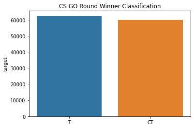

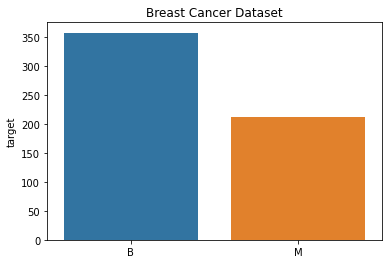

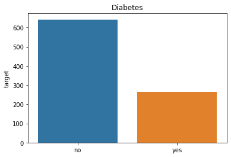

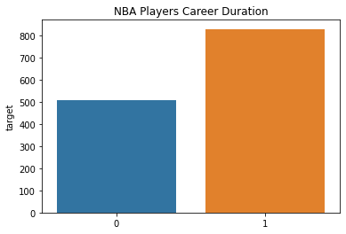

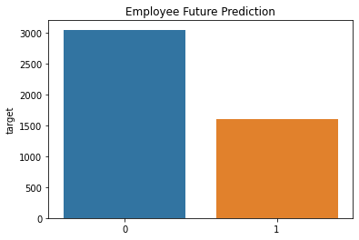

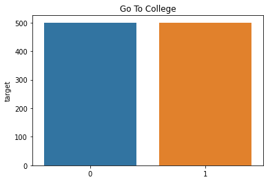

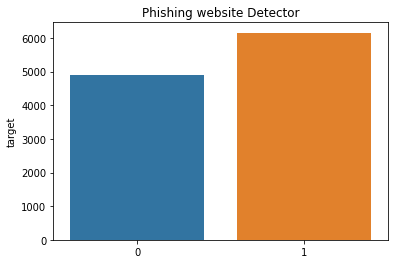

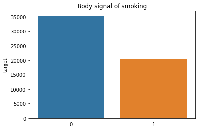

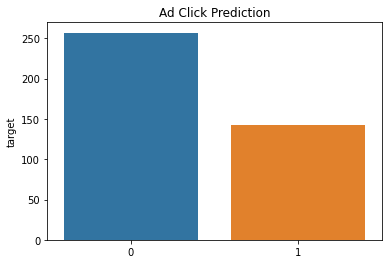

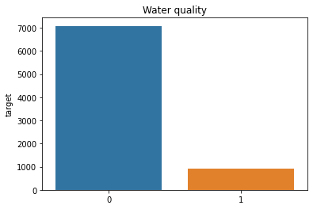

```python
import matplotlib.pyplot as plt

# Type of evaluation
scoring_choosed = [None] * 10

for i, dataset in enumerate(datasets):
    # To plot the proportion of classes, we first count the values of the 'target' column and transform them into a frame
    class_distribuition = pandas.DataFrame(dataset['target'].value_counts())

    # Plot classes
    plt.figure()

    # We use the frame created above to plot the frequency of each class in the dataset
    plot = seaborn.barplot(x=class_distribuition.index, y='target', data = class_distribuition)
    plot.set_title(datasets_names[i])

    # Verify distribution of target classes
    total_sum = sum(class_distribuition['target'])
    partition = total_sum/len(class_distribuition['target'])
    for value in class_distribuition['target']:
        if(0.9 * partition <= value <= 1.1 * partition):
            scoring_choosed[i] = "accuracy"
        else:
            scoring_choosed[i] = "balanced_accuracy"
            break
```

## Classification

```python
# Import classification methods
from sklearn.tree import DecisionTreeClassifier
from sklearn.neighbors import KNeighborsClassifier
from sklearn.naive_bayes import GaussianNB
from sklearn.neural_network import MLPClassifier
from sklearn.model_selection import GridSearchCV
```

```python
# Instantiate classifiers
DTC = DecisionTreeClassifier()
KNN = KNeighborsClassifier()
GNB = GaussianNB()
MLP = MLPClassifier()
```

Set all possible parameters for each classification method.

```python
DTC_parameters = {'criterion' : ['gini','entropy','log_loss'], 'random_state' : [42]}
KNN_parameters = {'n_neighbors' : [1, 3, 5, 7, 9, 11, 13], 'weights' : ['uniform', 'distance']}
GNB_parameters = {}
MLP_parameters = {'hidden_layer_sizes' : [(5), (8), (15), (5, 3), (8, 5), (10, 5)], 'max_iter' : [3000], 'random_state' : [42]}
```

Applying 10-fold cross validation (GridSearchCV) in the datasets.

```python
GS_DTC = [None] * 10
GS_KNN = [None] * 10
GS_GNB = [None] * 10
GS_MLP = [None] * 10

# Define grid search cv based on the paremeters defined above and corresponding evaluation method (scoring)
for i, choosed in enumerate(scoring_choosed):
    GS_DTC[i] = GridSearchCV(DTC, DTC_parameters, cv = 10, scoring = choosed)
    GS_KNN[i] = GridSearchCV(KNN, KNN_parameters, cv = 10, scoring = choosed)
    GS_GNB[i] = GridSearchCV(GNB, GNB_parameters, cv = 10, scoring = choosed)
    GS_MLP[i] = GridSearchCV(MLP, MLP_parameters, cv = 10, scoring = choosed)
```

```python
# Train and evaluate the classifier with the dataset
for i in range(len(datasets)):
    GS_DTC[i].fit(X[i], Y[i])
    GS_KNN[i].fit(X[i], Y[i])
    GS_GNB[i].fit(X[i], Y[i])
    GS_MLP[i].fit(X[i], Y[i])
```

Getting the results of training and evaluation.

```python
results_DTC = [None] * 10
results_KNN = [None] * 10
results_GNB = [None] * 10
results_MLP = [None] * 10

for i in range(len(datasets)):
    results_DTC[i] = pandas.DataFrame(GS_DTC[i].cv_results_)
    results_KNN[i] = pandas.DataFrame(GS_KNN[i].cv_results_)
    results_GNB[i] = pandas.DataFrame(GS_GNB[i].cv_results_)
    results_MLP[i] = pandas.DataFrame(GS_MLP[i].cv_results_)
```

Filter only the desired data from the results and sort by accuracy score.

```python
# Labels of data we want to analyse
view = ['params', 'mean_test_score','std_test_score', 'rank_test_score']

for i in range(len(datasets)):
    results_DTC[i] = results_DTC[i][view].sort_values(by='rank_test_score')
    results_KNN[i] = results_KNN[i][view].sort_values(by='rank_test_score')
    results_GNB[i] = results_GNB[i][view].sort_values(by='rank_test_score')
    results_MLP[i] = results_MLP[i][view].sort_values(by='rank_test_score')
```

Show the results.

```python
for i, dataset in enumerate(datasets_names):
    print(f'For dataset {dataset}:')
    print(f'\tThe accuracy of DTC classifier is: {results_DTC[i]["mean_test_score"][0] :.2%}')
    print(f'\tThe accuracy of KNN classifier is: {results_KNN[i]["mean_test_score"][0] :.2%}')
    print(f'\tThe accuracy of GNB classifier is: {results_GNB[i]["mean_test_score"][0] :.2%}')
    print(f'\tThe accuracy of MLP classifier is: {results_MLP[i]["mean_test_score"][0] :.2%}')
    print()
```

```
For dataset CS GO Round Winner Classification:
	The accuracy of DTC classifier is: 69.93%
	The accuracy of KNN classifier is: 66.99%
	The accuracy of GNB classifier is: 73.03%
	The accuracy of MLP classifier is: 74.07%

For dataset Breast Cancer Dataset:
	The accuracy of DTC classifier is: 92.54%
	The accuracy of KNN classifier is: 90.42%
	The accuracy of GNB classifier is: 92.65%
	The accuracy of MLP classifier is: 91.99%

For dataset Diabetes:
	The accuracy of DTC classifier is: 94.72%
	The accuracy of KNN classifier is: 92.97%
	The accuracy of GNB classifier is: 56.77%
	The accuracy of MLP classifier is: 93.11%

For dataset NBA Players Career Duration:
	The accuracy of DTC classifier is: 62.94%
	The accuracy of KNN classifier is: 58.71%
	The accuracy of GNB classifier is: 65.96%
	The accuracy of MLP classifier is: 65.50%

For dataset Employee Future Prediction:
	The accuracy of DTC classifier is: 77.69%
	The accuracy of KNN classifier is: 70.98%
	The accuracy of GNB classifier is: 67.09%
	The accuracy of MLP classifier is: 64.50%

For dataset Go To College:
	The accuracy of DTC classifier is: 83.10%
	The accuracy of KNN classifier is: 67.10%
	The accuracy of GNB classifier is: 72.40%
	The accuracy of MLP classifier is: 50.00%

For dataset Phishing website Detector:
	The accuracy of DTC classifier is: 96.09%
	The accuracy of KNN classifier is: 95.89%
	The accuracy of GNB classifier is: 64.44%
	The accuracy of MLP classifier is: 93.36%

For dataset Body signal of smoking:
	The accuracy of DTC classifier is: 79.57%
	The accuracy of KNN classifier is: 77.54%
	The accuracy of GNB classifier is: 74.24%
	The accuracy of MLP classifier is: 73.66%

For dataset Ad Click Prediction:
	The accuracy of DTC classifier is: 82.33%
	The accuracy of KNN classifier is: 78.08%
	The accuracy of GNB classifier is: 84.45%
	The accuracy of MLP classifier is: 50.00%

For dataset Water quality:
	The accuracy of DTC classifier is: 78.43%
	The accuracy of KNN classifier is: 57.12%
	The accuracy of GNB classifier is: 69.98%
	The accuracy of MLP classifier is: 76.46%
```

### Absolute difference

Analysis of results by selecting the two best algorithms of each dataset and, comparing the two, check the best one through the absolute difference.

First we show the raw data and sort the results by the mean test score.

```python
# Create list of lists
datasets_algs = [[] for _ in range(len(datasets))]

# Append results in the lists and show the mean test score and standard deviation test score of each method fro each dataset
for i, algs in enumerate(datasets_algs):
    algs.append({"name": "DTC", "results": results_DTC[i]})
    algs.append({"name": "KNN", "results": results_KNN[i]})
    algs.append({"name": "GNB", "results": results_GNB[i]})
    algs.append({"name": "MLP", "results": results_MLP[i]})
    algs.sort(key = lambda acc : acc["results"]["mean_test_score"][0], reverse = True)

    print(f'Dataset: {datasets_names[i]}')
    for alg in algs:
        print(f'\t{alg["name"]}: mean score: {alg["results"]["mean_test_score"][0]}, std: {alg["results"]["std_test_score"][0]}')
    print()
```

```
Dataset: CS GO Round Winner Classification
	MLP: mean score: 0.7407156278081856, std: 0.009854957169476897
	GNB: mean score: 0.7302671350379871, std: 0.007144051038205445
	DTC: mean score: 0.6992892737521443, std: 0.004474193623484673
	KNN: mean score: 0.6698880810391308, std: 0.008363147416997365

Dataset: Breast Cancer Dataset
	GNB: mean score: 0.9265331890331889, std: 0.03343992490690495
	DTC: mean score: 0.9253535353535354, std: 0.03879138010935533
	MLP: mean score: 0.9198737373737375, std: 0.02917625029840954
	KNN: mean score: 0.9041991341991343, std: 0.029975390688040598

Dataset: Diabetes
	DTC: mean score: 0.9471741452991452, std: 0.032332328890527
	MLP: mean score: 0.931090633903134, std: 0.0382692812873986
	KNN: mean score: 0.9296594551282051, std: 0.04477834365428389
	GNB: mean score: 0.5676923076923077, std: 0.033517227849046684

Dataset: NBA Players Career Duration
	GNB: mean score: 0.6595875940737741, std: 0.046693901679379236
	MLP: mean score: 0.6549766460801187, std: 0.045639366005169914
	DTC: mean score: 0.6294138571091088, std: 0.05034893262106421
	KNN: mean score: 0.5870593803786575, std: 0.038716673177205715

Dataset: Employee Future Prediction
	DTC: mean score: 0.7769499691953283, std: 0.02424809134516806
	KNN: mean score: 0.7098446373084754, std: 0.02901931371810383
	GNB: mean score: 0.6708712364727313, std: 0.026647786650621334
	MLP: mean score: 0.6449869080145719, std: 0.03896139659926067

Dataset: Go To College
	DTC: mean score: 0.8310000000000001, std: 0.031448370387032756
	GNB: mean score: 0.724, std: 0.03903844259188627
	KNN: mean score: 0.671, std: 0.05838664230797999
	MLP: mean score: 0.5, std: 0.0

Dataset: Phishing website Detector
	DTC: mean score: 0.9609371058763173, std: 0.02007056255384461
	KNN: mean score: 0.9588900925339597, std: 0.02311754156821395
	MLP: mean score: 0.9336383158339988, std: 0.009958544492410161
	GNB: mean score: 0.6444087213599409, std: 0.010951634908776433

Dataset: Body signal of smoking
	DTC: mean score: 0.7956665868596762, std: 0.10221020423081259
	KNN: mean score: 0.7753974429186485, std: 0.11237917107260173
	GNB: mean score: 0.7424087432689042, std: 0.0034920443454949848
	MLP: mean score: 0.7366309098261118, std: 0.013173753370281246

Dataset: Ad Click Prediction
	GNB: mean score: 0.8445384615384617, std: 0.10319403940155542
	DTC: mean score: 0.8232783882783883, std: 0.07175946134672376
	KNN: mean score: 0.7807875457875457, std: 0.08332644861469017
	MLP: mean score: 0.5, std: 0.0

Dataset: Water quality
	DTC: mean score: 0.7843089942611777, std: 0.13992236365517488
	MLP: mean score: 0.7646279119110273, std: 0.16454433973912516
	GNB: mean score: 0.6997862500532015, std: 0.14255836611335324
	KNN: mean score: 0.5712444007599436, std: 0.10922072695501586
```

Select the two best results and calculate the mean error, standard deviation of errors and the absolute difference for each datasets.

```python
from math import sqrt

absolute_difference = [None] * 10

for i, algs in enumerate(datasets_algs):
    mean_err_A0 = 1 - algs[0]["results"]["mean_test_score"][0]
    std_A0 = algs[0]["results"]["std_test_score"][0]

    mean_err_A1 = 1 - algs[1]["results"]["mean_test_score"][0]
    std_A1 = algs[1]["results"]["std_test_score"][0]

    dif_mean_err = mean_err_A0 - mean_err_A1
    std = sqrt( (std_A0**2 + std_A1**2) / 2.0 )
    absolute_difference[i] = dif_mean_err / std
```

Show the results calculated above.

```python
for i, algs in enumerate(datasets_algs):
    print(f'Dataset: {datasets_names[i]}, absolute difference: {absolute_difference[i]}')
    if absolute_difference[i] > 0:
        if absolute_difference[i] >= 2:
            print(f'{algs[1]["name"]} performs better than {algs[0]["name"]} with 95% confidence')
        else:
            print(f'{algs[1]["name"]} performs better than {algs[0]["name"]}')
    else:
        if absolute_difference[i] <= -2:
            print(f'{algs[0]["name"]} performs better than {algs[1]["name"]} with 95% confidence')
        else:
            print(f'{algs[0]["name"]} performs better than {algs[1]["name"]}')
    print()
```

```
Dataset: CS GO Round Winner Classification, absolute difference: -1.2139662411911816
MLP performs better than GNB

Dataset: Breast Cancer Dataset, absolute difference: -0.032573948099465254
GNB performs better than DTC

Dataset: Diabetes, absolute difference: -0.45401077062389245
DTC performs better than MLP

Dataset: NBA Players Career Duration, absolute difference: -0.09986968761929807
GNB performs better than MLP

Dataset: Employee Future Prediction, absolute difference: -2.5095177118972916
DTC performs better than KNN with 95% confidence

Dataset: Go To College, absolute difference: -3.018578894707481
DTC performs better than GNB with 95% confidence

Dataset: Phishing website Detector, absolute difference: -0.0945601955228326
DTC performs better than KNN

Dataset: Body signal of smoking, absolute difference: -0.18869921889651706
DTC performs better than KNN

Dataset: Ad Click Prediction, absolute difference: -0.23920639643380975
GNB performs better than DTC

Dataset: Water quality, absolute difference: -0.12886164988094084
DTC performs better than MLP
```

# Conclusion

After analysing the results we are to conclude that DTC performs well under different conditions aperring in 8 of our 10 top 2 algorithms.